# Ficha de Información Metropolitana

Universidad Autónoma Metropolitnana

Lic. Martínez Rodriguez, Alvaro[^1]

Lic. Pérez Victorino, Leonardo[^2]

La ficha de información metropolitana es una herramienta valiosa para la planificación territorial en zonas metropolitanas (ZM). Proporciona información censal en diferentes formatos, como gráficos, tablas y mapas, tanto de los Censos de Población y Vivienda, 2020 (CPV2020) como de los Censos Económicos de 1999, 2004, 2009, 2014 y 2019. Ambos publicados por el Instituto Nacional de Estadística y Geografía (INEGI).

## Información general de la Zona Metropolitana de Acayucan

Según (Sedatu 2018), la zona metropolitana se define como un área urbana que consta de una ciudad principal y su zona conurbada. Las zonas metropolitanas se caracterizan por tener una alta densidad de población y estar interconectadas por vías de transporte y comunicación. La zona metropolitana de Acayucan, se localiza en Veracruz de Ignacio de la Llave. y esta compuesta por 3 municipios, que se muestran a continuación:

| Nombre | Clave |
| --- | --- |
| Acayucan | 30003 |
| Oluta | 30116 |
| Soconusco | 30145 |

Municipios de la zona metropolitana

Además, se presenta un mapa de la zona metropolitana:

[interactive chart not shown]

A continuación se presentan algunos datos generales sobre esta zona:

- Zona Metropolitana:Acayucan
- Número de municipios: 3
- Población total: 114,416
- Superficie de la ZM: 828.49 [m^2]
- Densidad poblacional: 138.102 [1/m^2] Hab/Km^2.
- Grado promedio de escolaridad: 8.5933333

## Información sociodemográfica

La estructura de población de la zona metropolitana de Acayucan se presenta en la una piramide poblacional ya que permite obtener una visión general de la distribución de la población por género y edad:

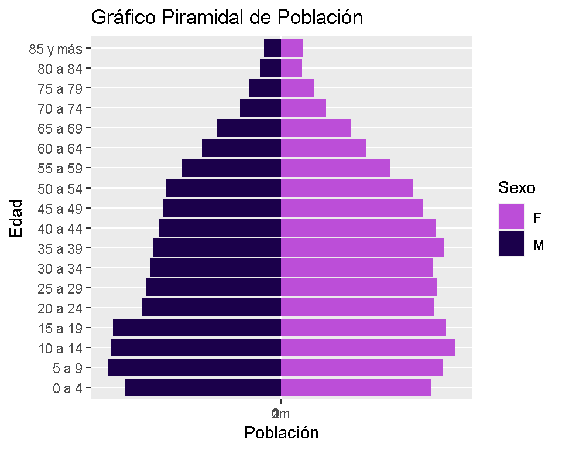

En el siguiente mapa se observa como se distribuye la población sobre la región:

[interactive chart not shown]

### Grupos de población

- Población total respecto al país: 0%. Este valor indica el peso poblacional de la zona metropolitana en relación con la población total de México.
- Población Masculina: 48%
- Población Femenina: 52%
- Relación M-F: 91.71. Este valor indica la proporción de hombres por cada mujer en la zona metropolitana.

### Socioeconómicos

La población en terminos de la poblacioón economicamente activa esta descrita por:

- Porcentaje de población de 12 años y más económicamente activa: 50%
- Porcentaje de población de 12 años y más no económicamente activa: 30% `

### Educación

La educación de la zona metropolitana esta caracterizada por los siguientes estadísticos:

- Porcentaje de población de 15 años y más sin escolaridad:8%
- Porcentaje de población de 15 años y más con al menos un grado aprobado en primaria: 70%
- Porcentaje de población de 15 años y más con educación básica completa: 14%
- Porcentaje de población de 15 años y más con secundaria o equivalente incompleta:2%
- Porcentaje de población de 18 años y más con al menos un grado aprobado en educación media superior: 29%

### Salud

La situación de la afiliación a algún servico de salud es la siguiente:

- Porcentaje de población afiliada a servicios de salud: 62%
- Población sin afiliación a servicios de salud:43683

### Indicadores de desarrollo

Finalmente se presentan tres indicadores de desarrollo; los índices son: índice de Desarrollo Humano (IDH), Índice de Marginación (IM) e Índice de Rezago Social (IRS).

IDH es un indicador elaborado por el Programa de Naciones Unidas para el Desarrollo (PNUD), este busca medir la calidad de vida, así como el progreso socioeconómico de cada entidad y municipio; El cálculo del Índice de Desarrollo Humano se realiza a partir de las tres variables: esperanza de vida, educación e ingreso per cápita.

- Muy Alto - IDH mayor de 1.
- Alto - IDH entre 0.80 a 1.
- Medio - IDH entre 0.50 y 0.80.
- Bajo - IDH entre 0 y 0.50
- Muy Bajo - IDH menores a 0.
- El promedio del IDH en 2020 para la zona metropolitana es de 0.726 según datos del PNUD.

## Datos económicos.

Con base en la información de los subsectores de los 21 sectores principales de la clasificación del SCIAN, extraída de los Censos Económicos del INEGI durante el periodo de 1998-2018, se ha llevado a cabo la agrupación de los datos de cada municipio que pertenece a una zona metropolitana en cinco grandes sectores: Primarios, Construcción, Manufactura, Comercio y Servicios. Esta clasificación se basa en la metodología proporcionada por el INEGI. Se utilizaron las siguientes variables:

- Unidades económicas (UE) [número de unidades]
- Activiso fijos totales (AF) [miles de pesos a precios corrientes]
- Formación bruta de capital fijo (FB) [miles de pesos a precios corrientes]
- Producción bruta total (PB) [miles de pesos a precios corrientes]
- Personal ocupado total (PO) [número de personas]
- Total de remuneraciones (RE) [miles de pesos a precios corrientes]
- Valor agregado censal bruto (VA) [miles de pesos a precios corrientes]

Posteriormente, se replica la metodología utilizada por García y Carranco (2008) para estimar los coeficientes de participación relativa (PR), de localización de la actividad económica (QL), Hirschman-Herfindahl (HH) e Inverso de Hirschman-Herfindahl (IHH).

$PR_ij$=$X_ij/X_in$

$QL_ij$=$(X_ij⁄X_j )/(X_in⁄X_n)$

$HH_ij$=$X_ij/X_in - X_j/X_n$

$IHH_ij$=$1/(X_ij/X_in - X_j/X_n)$

Donde:

- $X_ij$= Variable económica del sector i en el municipio j
- $X_j$= Variable económica del total de los sectores en el municipio j
- $X_in$= Variable económica del sector i de la Zona Metropolitana del municipio j
- $X_n$= Variable económica del total de los sectores de la Zona Metropolitana del municipio j

### Cifras brutas

#### 1999

##### UE

| Clave | Municipio | Primarios | Construcción | Manufactura | Comercio | Servicios |
| --- | --- | --- | --- | --- | --- | --- |
| 30003 | Acayucan | 0 | 0 | 259 | 1,567 | 1,162 |
| 30116 | Oluta | 0 | 0 | 55 | 172 | 107 |
| 30145 | Soconusco | 0 | 0 | 34 | 120 | 44 |

##### AF

| Clave | Municipio | Primarios | Construcción | Manufactura | Comercio | Servicios |
| --- | --- | --- | --- | --- | --- | --- |
| 30003 | Acayucan | 2,435 | 97 | 34,151 | 118,508 | 172,175 |
| 30116 | Oluta | 74 | 141 | 2,799 | 5,293 | 6,069 |
| 30145 | Soconusco | 8,264 | 1,599 | 1,047 | 3,737 | 2,863 |

##### FB

| Clave | Municipio | Primarios | Construcción | Manufactura | Comercio | Servicios |
| --- | --- | --- | --- | --- | --- | --- |
| 30003 | Acayucan | 130 | 0 | 890 | 1,663 | 2,807 |
| 30116 | Oluta | 35 | 0 | 76 | 16 | 23 |
| 30145 | Soconusco | 480 | 0 | 3 | 61 | -32 |

##### PB

| Clave | Municipio | Primarios | Construcción | Manufactura | Comercio | Servicios |
| --- | --- | --- | --- | --- | --- | --- |
| 30003 | Acayucan | 3,304 | 2,721 | 70,894 | 359,017 | 265,478 |
| 30116 | Oluta | 142 | 968 | 9,013 | 11,909 | 94,572 |
| 30145 | Soconusco | 7,965 | 4,464 | 2,125 | 2,762 | 3,959 |

##### PO

| Clave | Municipio | Primarios | Construcción | Manufactura | Comercio | Servicios |
| --- | --- | --- | --- | --- | --- | --- |
| 30003 | Acayucan | 35 | 13 | 795 | 3,885 | 3,895 |
| 30116 | Oluta | 3 | 4 | 143 | 289 | 223 |
| 30145 | Soconusco | 46 | 28 | 59 | 170 | 132 |

##### RE

| Clave | Municipio | Primarios | Construcción | Manufactura | Comercio | Servicios |
| --- | --- | --- | --- | --- | --- | --- |
| 30003 | Acayucan | 423 | 150 | 6,289 | 54,014 | 40,877 |
| 30116 | Oluta | 0 | 41 | 864 | 576 | 814 |
| 30145 | Soconusco | 964 | 345 | 42 | 124 | 304 |

##### VA

| Clave | Municipio | Primarios | Construcción | Manufactura | Comercio | Servicios |
| --- | --- | --- | --- | --- | --- | --- |
| 30003 | Acayucan | 764 | 583 | 23,204 | 258,477 | 143,105 |
| 30116 | Oluta | 93 | 132 | 3,767 | 10,459 | 79,736 |
| 30145 | Soconusco | 2,933 | 2,085 | 473 | 2,349 | 1,375 |

#### 2004

##### UE

| Clave | Municipio | Primarios | Construcción | Manufactura | Comercio | Servicios |
| --- | --- | --- | --- | --- | --- | --- |
| 30003 | Acayucan | 0 | 0 | 263 | 1,394 | 1,140 |
| 30116 | Oluta | 0 | 0 | 79 | 178 | 127 |
| 30145 | Soconusco | 0 | 0 | 36 | 92 | 20 |

##### AF

| Clave | Municipio | Primarios | Construcción | Manufactura | Comercio | Servicios |
| --- | --- | --- | --- | --- | --- | --- |
| 30003 | Acayucan | 12,636 | 3,851 | 47,167 | 157,543 | 267,126 |
| 30116 | Oluta | 16 | 803 | 4,173 | 7,836 | 18,429 |
| 30145 | Soconusco | 13,366 | 244 | 3,938 | 8,302 | 5,965 |

##### FB

| Clave | Municipio | Primarios | Construcción | Manufactura | Comercio | Servicios |
| --- | --- | --- | --- | --- | --- | --- |
| 30003 | Acayucan | 0 | 1,344 | 4,208 | 15,442 | 278,079 |
| 30116 | Oluta | 0 | 0 | 179 | 503 | 2,608 |
| 30145 | Soconusco | 1,100 | 0 | 1,279 | 36 | 29 |

##### PB

| Clave | Municipio | Primarios | Construcción | Manufactura | Comercio | Servicios |
| --- | --- | --- | --- | --- | --- | --- |
| 30003 | Acayucan | 28,377 | 21,470 | 101,202 | 588,392 | 646,556 |
| 30116 | Oluta | 20 | 3,179 | 12,203 | 16,999 | 287,039 |
| 30145 | Soconusco | 4,552 | 960 | 6,500 | 11,741 | 10,650 |

##### PO

| Clave | Municipio | Primarios | Construcción | Manufactura | Comercio | Servicios |
| --- | --- | --- | --- | --- | --- | --- |
| 30003 | Acayucan | 111 | 61 | 914 | 4,716 | 4,574 |
| 30116 | Oluta | 1 | 104 | 184 | 387 | 424 |
| 30145 | Soconusco | 28 | 32 | 84 | 230 | 115 |

##### RE

| Clave | Municipio | Primarios | Construcción | Manufactura | Comercio | Servicios |
| --- | --- | --- | --- | --- | --- | --- |
| 30003 | Acayucan | 573 | 998 | 17,556 | 138,477 | 101,963 |
| 30116 | Oluta | 0 | 1,819 | 1,822 | 2,183 | 2,773 |
| 30145 | Soconusco | 454 | 169 | 690 | 1,710 | 925 |

##### VA

| Clave | Municipio | Primarios | Construcción | Manufactura | Comercio | Servicios |
| --- | --- | --- | --- | --- | --- | --- |
| 30003 | Acayucan | 16,037 | 8,657 | 44,781 | 433,470 | 324,434 |
| 30116 | Oluta | 20 | 2,242 | 4,919 | 13,858 | 245,705 |
| 30145 | Soconusco | 2,768 | 334 | 3,308 | 8,679 | 5,294 |

#### 2009

##### UE

| Clave | Municipio | Primarios | Construcción | Manufactura | Comercio | Servicios |
| --- | --- | --- | --- | --- | --- | --- |
| 30003 | Acayucan | 0 | 7 | 311 | 1,726 | 1,440 |
| 30116 | Oluta | 0 | 0 | 82 | 246 | 137 |
| 30145 | Soconusco | 0 | 0 | 26 | 184 | 51 |

##### AF

| Clave | Municipio | Primarios | Construcción | Manufactura | Comercio | Servicios |
| --- | --- | --- | --- | --- | --- | --- |
| 30003 | Acayucan | 2,097 | 20,312 | 64,749 | 413,722 | 384,220 |
| 30116 | Oluta | 0 | 3,714 | 8,559 | 14,967 | 54,231 |
| 30145 | Soconusco | 3,097 | 17,880 | 2,274 | 12,474 | 11,319 |

##### FB

| Clave | Municipio | Primarios | Construcción | Manufactura | Comercio | Servicios |
| --- | --- | --- | --- | --- | --- | --- |
| 30003 | Acayucan | 0 | 132 | 3,683 | 34,667 | 18,611 |
| 30116 | Oluta | 0 | 0 | 76 | 94 | 123 |
| 30145 | Soconusco | 392 | 2,483 | 145 | 1,690 | 425 |

##### PB

| Clave | Municipio | Primarios | Construcción | Manufactura | Comercio | Servicios |
| --- | --- | --- | --- | --- | --- | --- |
| 30003 | Acayucan | 3,367 | 79,626 | 149,033 | 754,470 | 534,138 |
| 30116 | Oluta | 0 | 4,012 | 18,495 | 14,559 | 500,414 |
| 30145 | Soconusco | 3,520 | 23,371 | 4,398 | 15,181 | 17,792 |

##### PO

| Clave | Municipio | Primarios | Construcción | Manufactura | Comercio | Servicios |
| --- | --- | --- | --- | --- | --- | --- |
| 30003 | Acayucan | 29 | 189 | 1,028 | 5,609 | 5,140 |
| 30116 | Oluta | 0 | 23 | 272 | 541 | 617 |
| 30145 | Soconusco | 39 | 86 | 93 | 474 | 283 |

##### RE

| Clave | Municipio | Primarios | Construcción | Manufactura | Comercio | Servicios |
| --- | --- | --- | --- | --- | --- | --- |
| 30003 | Acayucan | 1,097 | 6,034 | 27,695 | 142,098 | 122,602 |
| 30116 | Oluta | 0 | 410 | 2,786 | 3,347 | 5,424 |
| 30145 | Soconusco | 867 | 3,347 | 752 | 4,700 | 5,048 |

##### VA

| Clave | Municipio | Primarios | Construcción | Manufactura | Comercio | Servicios |
| --- | --- | --- | --- | --- | --- | --- |
| 30003 | Acayucan | 2,340 | 24,129 | 68,243 | 473,577 | 282,731 |
| 30116 | Oluta | 0 | 1,170 | 7,205 | 9,398 | 358,502 |
| 30145 | Soconusco | 2,891 | -5,751 | 1,836 | 3,488 | 5,386 |

#### 2014

##### UE

| Clave | Municipio | Primarios | Construcción | Manufactura | Comercio | Servicios |
| --- | --- | --- | --- | --- | --- | --- |
| 30003 | Acayucan | 4 | 4 | 320 | 1,726 | 1,441 |
| 30116 | Oluta | 0 | 0 | 79 | 256 | 83 |
| 30145 | Soconusco | 0 | 0 | 44 | 210 | 95 |

##### AF

| Clave | Municipio | Primarios | Construcción | Manufactura | Comercio | Servicios |
| --- | --- | --- | --- | --- | --- | --- |
| 30003 | Acayucan | 266 | 19,581 | 138,751 | 942,765 | 491,015 |
| 30116 | Oluta | 0 | 0 | 5,956 | 16,016 | 6,469 |
| 30145 | Soconusco | 0 | 0 | 3,281 | 22,199 | 5,132 |

##### FB

| Clave | Municipio | Primarios | Construcción | Manufactura | Comercio | Servicios |
| --- | --- | --- | --- | --- | --- | --- |
| 30003 | Acayucan | 0 | -589 | 4,880 | -27,120 | 28,076 |
| 30116 | Oluta | 0 | 0 | 319 | 3,698 | 114 |
| 30145 | Soconusco | 0 | 0 | 5 | 395 | 91 |

##### PB

| Clave | Municipio | Primarios | Construcción | Manufactura | Comercio | Servicios |
| --- | --- | --- | --- | --- | --- | --- |
| 30003 | Acayucan | 277 | 16,998 | 144,679 | 1,221,223 | 680,405 |
| 30116 | Oluta | 0 | 0 | 14,485 | 30,117 | 10,577 |
| 30145 | Soconusco | 0 | 0 | 9,568 | 31,454 | 8,301 |

##### PO

| Clave | Municipio | Primarios | Construcción | Manufactura | Comercio | Servicios |
| --- | --- | --- | --- | --- | --- | --- |
| 30003 | Acayucan | 19 | 90 | 835 | 5,038 | 4,368 |
| 30116 | Oluta | 0 | 0 | 156 | 448 | 188 |
| 30145 | Soconusco | 0 | 0 | 97 | 394 | 158 |

##### RE

| Clave | Municipio | Primarios | Construcción | Manufactura | Comercio | Servicios |
| --- | --- | --- | --- | --- | --- | --- |
| 30003 | Acayucan | 48 | 4,001 | 25,547 | 166,950 | 109,365 |
| 30116 | Oluta | 0 | 0 | 1,788 | 4,581 | 1,874 |
| 30145 | Soconusco | 0 | 0 | 975 | 5,594 | 942 |

##### VA

| Clave | Municipio | Primarios | Construcción | Manufactura | Comercio | Servicios |
| --- | --- | --- | --- | --- | --- | --- |
| 30003 | Acayucan | 53 | 7,514 | 70,971 | 819,638 | 370,040 |
| 30116 | Oluta | 0 | 0 | 6,706 | 22,428 | 6,081 |
| 30145 | Soconusco | 0 | 0 | 4,167 | 24,817 | 3,249 |

#### 2019

##### UE

| Clave | Municipio | Primarios | Construcción | Manufactura | Comercio | Servicios |
| --- | --- | --- | --- | --- | --- | --- |
| 30003 | Acayucan | 5 | 6 | 354 | 1,946 | 1,707 |
| 30116 | Oluta | 0 | 1 | 146 | 367 | 291 |
| 30145 | Soconusco | 1 | 1 | 50 | 208 | 117 |

##### AF

| Clave | Municipio | Primarios | Construcción | Manufactura | Comercio | Servicios |
| --- | --- | --- | --- | --- | --- | --- |
| 30003 | Acayucan | 0 | 0 | 196,178 | 1,451,955 | 531,178 |
| 30116 | Oluta | 0 | 0 | 19,615 | 49,689 | 45,845 |
| 30145 | Soconusco | 0 | 0 | 4,362 | 27,514 | 12,608 |

##### FB

| Clave | Municipio | Primarios | Construcción | Manufactura | Comercio | Servicios |
| --- | --- | --- | --- | --- | --- | --- |
| 30003 | Acayucan | 0 | 0 | 2,248 | 251,508 | 35,597 |
| 30116 | Oluta | 0 | 0 | 1,014 | 1,105 | 670 |
| 30145 | Soconusco | 0 | 0 | 4 | 622 | 841 |

##### PB

| Clave | Municipio | Primarios | Construcción | Manufactura | Comercio | Servicios |
| --- | --- | --- | --- | --- | --- | --- |
| 30003 | Acayucan | 0 | 0 | 378,755 | 2,279,182 | 918,129 |
| 30116 | Oluta | 0 | 0 | 39,065 | 53,092 | 54,114 |
| 30145 | Soconusco | 0 | 0 | 12,276 | 30,825 | 31,896 |

##### PO

| Clave | Municipio | Primarios | Construcción | Manufactura | Comercio | Servicios |
| --- | --- | --- | --- | --- | --- | --- |
| 30003 | Acayucan | 0 | 0 | 995 | 6,329 | 4,728 |
| 30116 | Oluta | 0 | 0 | 331 | 681 | 707 |
| 30145 | Soconusco | 0 | 0 | 71 | 290 | 317 |

##### RE

| Clave | Municipio | Primarios | Construcción | Manufactura | Comercio | Servicios |
| --- | --- | --- | --- | --- | --- | --- |
| 30003 | Acayucan | 0 | 0 | 32,610 | 279,240 | 159,453 |
| 30116 | Oluta | 0 | 0 | 3,325 | 8,072 | 7,204 |
| 30145 | Soconusco | 0 | 0 | 825 | 3,563 | 7,420 |

##### VA

| Clave | Municipio | Primarios | Construcción | Manufactura | Comercio | Servicios |
| --- | --- | --- | --- | --- | --- | --- |
| 30003 | Acayucan | 0 | 0 | 127,747 | 1,734,244 | 412,201 |
| 30116 | Oluta | 0 | 0 | 12,709 | 41,706 | 25,217 |
| 30145 | Soconusco | 0 | 0 | 4,031 | 26,733 | 13,145 |

### Coeficientes de localización (QL)

#### 1999

##### UE

| Clave | Municipio | Primarios | Construcción | Manufactura | Comercio | Servicios |
| --- | --- | --- | --- | --- | --- | --- |
| 30003 | Acayucan | 0.0000 | 0.0000 | 0.7812 | 0.9940 | 1.1022 |
| 30116 | Oluta | 0.0000 | 0.0000 | 1.4841 | 0.9760 | 0.9080 |
| 30145 | Soconusco | 0.0000 | 0.0000 | 1.5476 | 1.1487 | 0.6298 |

##### AF

| Clave | Municipio | Primarios | Construcción | Manufactura | Comercio | Servicios |
| --- | --- | --- | --- | --- | --- | --- |
| 30003 | Acayucan | 0.3056 | 0.0195 | 0.3066 | 4.7664 | 0.9664 |
| 30116 | Oluta | 0.2115 | 0.6442 | 0.5722 | 4.8477 | 0.7757 |
| 30145 | Soconusco | 19.3920 | 5.9977 | 0.1757 | 2.8100 | 0.3004 |

##### FB

[output not shown]

##### PB

| Clave | Municipio | Primarios | Construcción | Manufactura | Comercio | Servicios |
| --- | --- | --- | --- | --- | --- | --- |
| 30003 | Acayucan | 0.4720 | 0.1075 | 0.2043 | 3.6630 | 1.1851 |
| 30116 | Oluta | 0.1220 | 0.2301 | 0.1562 | 0.7309 | 2.5394 |
| 30145 | Soconusco | 37.5167 | 5.8149 | 0.2019 | 0.9291 | 0.5826 |

##### PO

| Clave | Municipio | Primarios | Construcción | Manufactura | Comercio | Servicios |
| --- | --- | --- | --- | --- | --- | --- |
| 30003 | Acayucan | 0.4576 | 0.0281 | 0.2987 | 1.7364 | 1.2232 |
| 30116 | Oluta | 0.5109 | 0.1125 | 0.6998 | 1.6825 | 0.9122 |
| 30145 | Soconusco | 11.9214 | 1.1987 | 0.4394 | 1.5062 | 0.8217 |

##### RE

| Clave | Municipio | Primarios | Construcción | Manufactura | Comercio | Servicios |
| --- | --- | --- | --- | --- | --- | --- |
| 30003 | Acayucan | 0.3666 | 0.0574 | 0.1672 | 3.7382 | 0.8903 |
| 30116 | Oluta | 0.0000 | 0.6952 | 1.0182 | 1.7674 | 0.7861 |
| 30145 | Soconusco | 47.7833 | 7.5463 | 0.0639 | 0.4909 | 0.3787 |

##### VA

| Clave | Municipio | Primarios | Construcción | Manufactura | Comercio | Servicios |
| --- | --- | --- | --- | --- | --- | --- |
| 30003 | Acayucan | 0.1525 | 0.0615 | 0.1478 | 2.7232 | 0.8960 |
| 30116 | Oluta | 0.0840 | 0.0630 | 0.1085 | 0.4985 | 2.2586 |
| 30145 | Soconusco | 27.0708 | 10.1773 | 0.1393 | 1.1444 | 0.3981 |

#### 2004

##### UE

| Clave | Municipio | Primarios | Construcción | Manufactura | Comercio | Servicios |
| --- | --- | --- | --- | --- | --- | --- |
| 30003 | Acayucan | 0.0000 | 0.0000 | 0.9620 | 0.9231 | 1.1463 |
| 30116 | Oluta | 0.0000 | 0.0000 | 2.1047 | 0.8585 | 0.9301 |
| 30145 | Soconusco | 0.0000 | 0.0000 | 2.4885 | 1.1513 | 0.3801 |

##### AF

| Clave | Municipio | Primarios | Construcción | Manufactura | Comercio | Servicios |
| --- | --- | --- | --- | --- | --- | --- |
| 30003 | Acayucan | 1.5559 | 0.7178 | 0.2637 | 3.5872 | 1.0599 |
| 30116 | Oluta | 0.0308 | 2.3383 | 0.3644 | 2.7875 | 1.1424 |
| 30145 | Soconusco | 25.2611 | 0.6981 | 0.3379 | 2.9015 | 0.3633 |

##### FB

[output not shown]

##### PB

| Clave | Municipio | Primarios | Construcción | Manufactura | Comercio | Servicios |
| --- | --- | --- | --- | --- | --- | --- |
| 30003 | Acayucan | 2.0036 | 0.4894 | 0.1581 | 3.0907 | 1.2998 |
| 30116 | Oluta | 0.0061 | 0.3144 | 0.0827 | 0.3874 | 2.5038 |
| 30145 | Soconusco | 12.9483 | 0.8816 | 0.4091 | 2.4846 | 0.8626 |

##### PO

| Clave | Municipio | Primarios | Construcción | Manufactura | Comercio | Servicios |
| --- | --- | --- | --- | --- | --- | --- |
| 30003 | Acayucan | 1.2942 | 0.1271 | 0.3343 | 1.5546 | 1.1314 |
| 30116 | Oluta | 0.1100 | 2.0440 | 0.6349 | 1.2034 | 0.9893 |
| 30145 | Soconusco | 6.9274 | 1.4147 | 0.6520 | 1.6088 | 0.6036 |

##### RE

| Clave | Municipio | Primarios | Construcción | Manufactura | Comercio | Servicios |
| --- | --- | --- | --- | --- | --- | --- |
| 30003 | Acayucan | 0.2319 | 0.1472 | 0.1929 | 3.4124 | 0.8590 |
| 30116 | Oluta | 0.0000 | 8.1028 | 0.6043 | 1.6242 | 0.7053 |
| 30145 | Soconusco | 12.0794 | 1.6393 | 0.4983 | 2.7705 | 0.5123 |

##### VA

| Clave | Municipio | Primarios | Construcción | Manufactura | Comercio | Servicios |
| --- | --- | --- | --- | --- | --- | --- |
| 30003 | Acayucan | 1.2030 | 0.4682 | 0.1665 | 2.6594 | 0.8922 |
| 30116 | Oluta | 0.0047 | 0.3761 | 0.0567 | 0.2637 | 2.0958 |
| 30145 | Soconusco | 8.4285 | 0.7333 | 0.4993 | 2.1614 | 0.5909 |

#### 2009

##### UE

| Clave | Municipio | Primarios | Construcción | Manufactura | Comercio | Servicios |
| --- | --- | --- | --- | --- | --- | --- |
| 30003 | Acayucan | 0.0000 | 0.3376 | 0.8667 | 0.9743 | 1.0845 |
| 30116 | Oluta | 0.0000 | 0.0000 | 1.7121 | 1.0404 | 0.7731 |
| 30145 | Soconusco | 0.0000 | 0.0000 | 0.9672 | 1.3865 | 0.5127 |

##### AF

| Clave | Municipio | Primarios | Construcción | Manufactura | Comercio | Servicios |
| --- | --- | --- | --- | --- | --- | --- |
| 30003 | Acayucan | 0.1250 | 1.4452 | 0.2735 | 4.9708 | 0.7191 |
| 30116 | Oluta | 0.0000 | 2.8708 | 0.3928 | 1.9536 | 1.1027 |
| 30145 | Soconusco | 3.4732 | 23.9348 | 0.1807 | 2.8197 | 0.3986 |

##### FB

[output not shown]

##### PB

| Clave | Municipio | Primarios | Construcción | Manufactura | Comercio | Servicios |
| --- | --- | --- | --- | --- | --- | --- |
| 30003 | Acayucan | 0.1223 | 1.2387 | 0.2020 | 4.7423 | 1.0045 |
| 30116 | Oluta | 0.0000 | 0.1766 | 0.0709 | 0.2589 | 2.6624 |
| 30145 | Soconusco | 3.0246 | 8.6029 | 0.1410 | 2.2580 | 0.7917 |

##### PO

| Clave | Municipio | Primarios | Construcción | Manufactura | Comercio | Servicios |
| --- | --- | --- | --- | --- | --- | --- |
| 30003 | Acayucan | 0.3387 | 0.3965 | 0.3605 | 1.6446 | 0.9941 |
| 30116 | Oluta | 0.0000 | 0.3983 | 0.7874 | 1.3095 | 0.9852 |
| 30145 | Soconusco | 5.6030 | 2.2193 | 0.4012 | 1.7098 | 0.6734 |

##### RE

| Clave | Municipio | Primarios | Construcción | Manufactura | Comercio | Servicios |
| --- | --- | --- | --- | --- | --- | --- |
| 30003 | Acayucan | 0.2703 | 0.5379 | 0.2805 | 3.7216 | 0.8322 |
| 30116 | Oluta | 0.0000 | 0.9149 | 0.7061 | 2.1941 | 0.9215 |
| 30145 | Soconusco | 4.3486 | 6.0742 | 0.1550 | 2.5058 | 0.6975 |

##### VA

| Clave | Municipio | Primarios | Construcción | Manufactura | Comercio | Servicios |
| --- | --- | --- | --- | --- | --- | --- |
| 30003 | Acayucan | 0.0969 | 0.9578 | 0.2263 | 3.8581 | 0.7493 |
| 30116 | Oluta | 0.0000 | 0.1050 | 0.0540 | 0.1732 | 2.1489 |
| 30145 | Soconusco | 12.9799 | -24.7489 | 0.6599 | 3.0805 | 1.5475 |

#### 2014

##### UE

| Clave | Municipio | Primarios | Construcción | Manufactura | Comercio | Servicios |
| --- | --- | --- | --- | --- | --- | --- |
| 30003 | Acayucan | 0.6773 | 0.2293 | 0.9323 | 1.0117 | 1.0131 |
| 30116 | Oluta | 0.0000 | 0.0000 | 1.9244 | 1.2547 | 0.4879 |
| 30145 | Soconusco | 0.0000 | 0.0000 | 1.2837 | 1.2327 | 0.6688 |

##### AF

| Clave | Municipio | Primarios | Construcción | Manufactura | Comercio | Servicios |
| --- | --- | --- | --- | --- | --- | --- |
| 30003 | Acayucan | 0.0127 | 0.9401 | 0.3187 | 5.3860 | 0.5222 |
| 30116 | Oluta | 0.0000 | 0.0000 | 0.7659 | 5.1229 | 0.3852 |
| 30145 | Soconusco | 0.0000 | 0.0000 | 0.3920 | 6.5970 | 0.2839 |

##### FB

[output not shown]

##### PB

| Clave | Municipio | Primarios | Construcción | Manufactura | Comercio | Servicios |
| --- | --- | --- | --- | --- | --- | --- |
| 30003 | Acayucan | 0.0238 | 0.2721 | 0.1435 | 4.9632 | 0.9258 |
| 30116 | Oluta | 0.0000 | 0.0000 | 0.5372 | 4.5775 | 0.5382 |
| 30145 | Soconusco | 0.0000 | 0.0000 | 0.3970 | 5.3483 | 0.4725 |

##### PO

| Clave | Municipio | Primarios | Construcción | Manufactura | Comercio | Servicios |
| --- | --- | --- | --- | --- | --- | --- |
| 30003 | Acayucan | 0.4511 | 0.2909 | 0.3339 | 1.7068 | 0.9608 |
| 30116 | Oluta | 0.0000 | 0.0000 | 0.8152 | 1.9834 | 0.5404 |
| 30145 | Soconusco | 0.0000 | 0.0000 | 0.6186 | 2.1287 | 0.5543 |

##### RE

| Clave | Municipio | Primarios | Construcción | Manufactura | Comercio | Servicios |
| --- | --- | --- | --- | --- | --- | --- |
| 30003 | Acayucan | 0.0096 | 0.5581 | 0.2446 | 3.9706 | 0.7426 |
| 30116 | Oluta | 0.0000 | 0.0000 | 0.6354 | 4.0433 | 0.4722 |
| 30145 | Soconusco | 0.0000 | 0.0000 | 0.3802 | 5.4186 | 0.2605 |

##### VA

| Clave | Municipio | Primarios | Construcción | Manufactura | Comercio | Servicios |
| --- | --- | --- | --- | --- | --- | --- |
| 30003 | Acayucan | 0.0054 | 0.2690 | 0.1664 | 3.6625 | 0.6377 |
| 30116 | Oluta | 0.0000 | 0.0000 | 0.5663 | 3.6092 | 0.3774 |
| 30145 | Soconusco | 0.0000 | 0.0000 | 0.3844 | 4.3631 | 0.2203 |

#### 2019

##### UE

| Clave | Municipio | Primarios | Construcción | Manufactura | Comercio | Servicios |
| --- | --- | --- | --- | --- | --- | --- |
| 30003 | Acayucan | 0.5238 | 0.2879 | 0.8913 | 1.0326 | 1.0007 |
| 30116 | Oluta | 0.0000 | 0.2395 | 1.8347 | 0.9720 | 0.8515 |
| 30145 | Soconusco | 1.1164 | 0.5113 | 1.3417 | 1.1763 | 0.7310 |

##### AF

| Clave | Municipio | Primarios | Construcción | Manufactura | Comercio | Servicios |
| --- | --- | --- | --- | --- | --- | --- |
| 30003 | Acayucan | 0.0000 | 0.0000 | 0.3178 | 3.4034 | 0.4941 |
| 30116 | Oluta | 0.0000 | 0.0000 | 0.6013 | 2.2044 | 0.8071 |
| 30145 | Soconusco | 0.0000 | 0.0000 | 0.3461 | 3.1596 | 0.5746 |

##### FB

[output not shown]

##### PB

| Clave | Municipio | Primarios | Construcción | Manufactura | Comercio | Servicios |
| --- | --- | --- | --- | --- | --- | --- |
| 30003 | Acayucan | 0.0000 | 0.0000 | 0.2122 | 4.5602 | 0.7823 |
| 30116 | Oluta | 0.0000 | 0.0000 | 0.5350 | 2.5971 | 1.1272 |
| 30145 | Soconusco | 0.0000 | 0.0000 | 0.3279 | 2.9409 | 1.2958 |

##### PO

| Clave | Municipio | Primarios | Construcción | Manufactura | Comercio | Servicios |
| --- | --- | --- | --- | --- | --- | --- |
| 30003 | Acayucan | 0.0000 | 0.0000 | 0.3361 | 2.0326 | 0.8467 |
| 30116 | Oluta | 0.0000 | 0.0000 | 0.7839 | 1.5334 | 0.8877 |
| 30145 | Soconusco | 0.0000 | 0.0000 | 0.4263 | 1.6555 | 1.0092 |

##### RE

| Clave | Municipio | Primarios | Construcción | Manufactura | Comercio | Servicios |
| --- | --- | --- | --- | --- | --- | --- |
| 30003 | Acayucan | 0.0000 | 0.0000 | 0.1914 | 4.3795 | 0.7064 |
| 30116 | Oluta | 0.0000 | 0.0000 | 0.4944 | 3.2077 | 0.8087 |
| 30145 | Soconusco | 0.0000 | 0.0000 | 0.1932 | 2.2304 | 1.3121 |

##### VA

| Clave | Municipio | Primarios | Construcción | Manufactura | Comercio | Servicios |
| --- | --- | --- | --- | --- | --- | --- |
| 30003 | Acayucan | 0.0000 | 0.0000 | 0.1641 | 3.4533 | 0.4421 |
| 30116 | Oluta | 0.0000 | 0.0000 | 0.4662 | 2.3717 | 0.7723 |
| 30145 | Soconusco | 0.0000 | 0.0000 | 0.2682 | 2.7571 | 0.7302 |

### Participación Relativa (PR)

#### 1999

##### UE

| Clave | Municipio | Primarios | Construcción | Manufactura | Comercio | Servicios |
| --- | --- | --- | --- | --- | --- | --- |
| 30003 | Acayucan | 0.0000 | 0.0000 | 0.0013 | 0.0016 | 0.0018 |
| 30116 | Oluta | 0.0000 | 0.0000 | 0.0003 | 0.0002 | 0.0002 |
| 30145 | Soconusco | 0.0000 | 0.0000 | 0.0002 | 0.0001 | 0.0001 |

##### AF

| Clave | Municipio | Primarios | Construcción | Manufactura | Comercio | Servicios |
| --- | --- | --- | --- | --- | --- | --- |
| 30003 | Acayucan | 0e+00 | 0.0000 | 0.0000 | 7e-04 | 1e-04 |
| 30116 | Oluta | 0e+00 | 0.0000 | 0.0000 | 0e+00 | 0e+00 |
| 30145 | Soconusco | 2e-04 | 0.0000 | 0.0000 | 0e+00 | 0e+00 |

##### FB

[output not shown]

##### PB

| Clave | Municipio | Primarios | Construcción | Manufactura | Comercio | Servicios |
| --- | --- | --- | --- | --- | --- | --- |
| 30003 | Acayucan | 1e-04 | 0.0000 | 0.0000 | 8e-04 | 3e-04 |
| 30116 | Oluta | 0e+00 | 0.0000 | 0.0000 | 0e+00 | 1e-04 |
| 30145 | Soconusco | 2e-04 | 0.0000 | 0.0000 | 0e+00 | 0e+00 |

##### PO

| Clave | Municipio | Primarios | Construcción | Manufactura | Comercio | Servicios |
| --- | --- | --- | --- | --- | --- | --- |
| 30003 | Acayucan | 4e-04 | 0.0000 | 2e-04 | 0.0013 | 9e-04 |
| 30116 | Oluta | 0e+00 | 0.0000 | 0e+00 | 0.0001 | 1e-04 |
| 30145 | Soconusco | 5e-04 | 0.0000 | 0e+00 | 0.0001 | 0e+00 |

##### RE

| Clave | Municipio | Primarios | Construcción | Manufactura | Comercio | Servicios |
| --- | --- | --- | --- | --- | --- | --- |
| 30003 | Acayucan | 1e-04 | 0.0000 | 0.0000 | 8e-04 | 2e-04 |
| 30116 | Oluta | 0e+00 | 0.0000 | 0.0000 | 0e+00 | 0e+00 |
| 30145 | Soconusco | 2e-04 | 0.0000 | 0.0000 | 0e+00 | 0e+00 |

##### VA

| Clave | Municipio | Primarios | Construcción | Manufactura | Comercio | Servicios |
| --- | --- | --- | --- | --- | --- | --- |
| 30003 | Acayucan | 0e+00 | 0e+00 | 0.0000 | 9e-04 | 3e-04 |
| 30116 | Oluta | 0e+00 | 0e+00 | 0.0000 | 0e+00 | 2e-04 |
| 30145 | Soconusco | 2e-04 | 1e-04 | 0.0000 | 0e+00 | 0e+00 |

#### 2004

##### UE

| Clave | Municipio | Primarios | Construcción | Manufactura | Comercio | Servicios |
| --- | --- | --- | --- | --- | --- | --- |
| 30003 | Acayucan | 0.0000 | 0.0000 | 0.0014 | 0.0013 | 0.0016 |
| 30116 | Oluta | 0.0000 | 0.0000 | 0.0004 | 0.0002 | 0.0002 |
| 30145 | Soconusco | 0.0000 | 0.0000 | 0.0002 | 0.0001 | 0.0000 |

##### AF

| Clave | Municipio | Primarios | Construcción | Manufactura | Comercio | Servicios |
| --- | --- | --- | --- | --- | --- | --- |
| 30003 | Acayucan | 3e-04 | 1e-04 | 0.0000 | 6e-04 | 2e-04 |
| 30116 | Oluta | 0e+00 | 0e+00 | 0.0000 | 0e+00 | 0e+00 |
| 30145 | Soconusco | 3e-04 | 0e+00 | 0.0000 | 0e+00 | 0e+00 |

##### FB

[output not shown]

##### PB

| Clave | Municipio | Primarios | Construcción | Manufactura | Comercio | Servicios |
| --- | --- | --- | --- | --- | --- | --- |
| 30003 | Acayucan | 5e-04 | 1e-04 | 0.0000 | 8e-04 | 4e-04 |
| 30116 | Oluta | 0e+00 | 0e+00 | 0.0000 | 0e+00 | 2e-04 |
| 30145 | Soconusco | 1e-04 | 0e+00 | 0.0000 | 0e+00 | 0e+00 |

##### PO

| Clave | Municipio | Primarios | Construcción | Manufactura | Comercio | Servicios |
| --- | --- | --- | --- | --- | --- | --- |
| 30003 | Acayucan | 1e-03 | 1e-04 | 3e-04 | 0.0013 | 9e-04 |
| 30116 | Oluta | 0e+00 | 2e-04 | 1e-04 | 0.0001 | 1e-04 |
| 30145 | Soconusco | 3e-04 | 1e-04 | 0e+00 | 0.0001 | 0e+00 |

##### RE

| Clave | Municipio | Primarios | Construcción | Manufactura | Comercio | Servicios |
| --- | --- | --- | --- | --- | --- | --- |
| 30003 | Acayucan | 1e-04 | 1e-04 | 1e-04 | 0.0012 | 3e-04 |
| 30116 | Oluta | 0e+00 | 1e-04 | 0e+00 | 0.0000 | 0e+00 |
| 30145 | Soconusco | 1e-04 | 0e+00 | 0e+00 | 0.0000 | 0e+00 |

##### VA

| Clave | Municipio | Primarios | Construcción | Manufactura | Comercio | Servicios |
| --- | --- | --- | --- | --- | --- | --- |
| 30003 | Acayucan | 4e-04 | 2e-04 | 1e-04 | 9e-04 | 3e-04 |
| 30116 | Oluta | 0e+00 | 0e+00 | 0e+00 | 0e+00 | 2e-04 |
| 30145 | Soconusco | 1e-04 | 0e+00 | 0e+00 | 0e+00 | 0e+00 |

#### 2009

##### UE

| Clave | Municipio | Primarios | Construcción | Manufactura | Comercio | Servicios |
| --- | --- | --- | --- | --- | --- | --- |
| 30003 | Acayucan | 0.0000 | 5e-04 | 0.0013 | 0.0014 | 0.0016 |
| 30116 | Oluta | 0.0000 | 0e+00 | 0.0003 | 0.0002 | 0.0001 |
| 30145 | Soconusco | 0.0000 | 0e+00 | 0.0001 | 0.0002 | 0.0001 |

##### AF

| Clave | Municipio | Primarios | Construcción | Manufactura | Comercio | Servicios |
| --- | --- | --- | --- | --- | --- | --- |
| 30003 | Acayucan | 0.0000 | 3e-04 | 1e-04 | 9e-04 | 1e-04 |
| 30116 | Oluta | 0.0000 | 0e+00 | 0e+00 | 0e+00 | 0e+00 |
| 30145 | Soconusco | 0.0000 | 2e-04 | 0e+00 | 0e+00 | 0e+00 |

##### FB

[output not shown]

##### PB

| Clave | Municipio | Primarios | Construcción | Manufactura | Comercio | Servicios |
| --- | --- | --- | --- | --- | --- | --- |
| 30003 | Acayucan | 0.0000 | 2e-04 | 0.0000 | 8e-04 | 2e-04 |
| 30116 | Oluta | 0.0000 | 0e+00 | 0.0000 | 0e+00 | 2e-04 |
| 30145 | Soconusco | 0.0000 | 1e-04 | 0.0000 | 0e+00 | 0e+00 |

##### PO

| Clave | Municipio | Primarios | Construcción | Manufactura | Comercio | Servicios |
| --- | --- | --- | --- | --- | --- | --- |
| 30003 | Acayucan | 3e-04 | 3e-04 | 3e-04 | 0.0012 | 8e-04 |
| 30116 | Oluta | 0e+00 | 0e+00 | 1e-04 | 0.0001 | 1e-04 |
| 30145 | Soconusco | 3e-04 | 1e-04 | 0e+00 | 0.0001 | 0e+00 |

##### RE

| Clave | Municipio | Primarios | Construcción | Manufactura | Comercio | Servicios |
| --- | --- | --- | --- | --- | --- | --- |
| 30003 | Acayucan | 1e-04 | 2e-04 | 1e-04 | 0.0011 | 3e-04 |
| 30116 | Oluta | 0e+00 | 0e+00 | 0e+00 | 0.0000 | 0e+00 |
| 30145 | Soconusco | 1e-04 | 1e-04 | 0e+00 | 0.0000 | 0e+00 |

##### VA

| Clave | Municipio | Primarios | Construcción | Manufactura | Comercio | Servicios |
| --- | --- | --- | --- | --- | --- | --- |
| 30003 | Acayucan | 0.0000 | 2e-04 | 1e-04 | 9e-04 | 2e-04 |
| 30116 | Oluta | 0.0000 | 0e+00 | 0e+00 | 0e+00 | 2e-04 |
| 30145 | Soconusco | 0.0000 | -1e-04 | 0e+00 | 0e+00 | 0e+00 |

#### 2014

##### UE

| Clave | Municipio | Primarios | Construcción | Manufactura | Comercio | Servicios |
| --- | --- | --- | --- | --- | --- | --- |
| 30003 | Acayucan | 9e-04 | 3e-04 | 0.0012 | 0.0013 | 0.0013 |
| 30116 | Oluta | 0e+00 | 0e+00 | 0.0003 | 0.0002 | 0.0001 |
| 30145 | Soconusco | 0e+00 | 0e+00 | 0.0002 | 0.0002 | 0.0001 |

##### AF

| Clave | Municipio | Primarios | Construcción | Manufactura | Comercio | Servicios |
| --- | --- | --- | --- | --- | --- | --- |
| 30003 | Acayucan | 0.0000 | 3e-04 | 1e-04 | 0.0015 | 1e-04 |
| 30116 | Oluta | 0.0000 | 0e+00 | 0e+00 | 0.0000 | 0e+00 |
| 30145 | Soconusco | 0.0000 | 0e+00 | 0e+00 | 0.0000 | 0e+00 |

##### FB

[output not shown]

##### PB

| Clave | Municipio | Primarios | Construcción | Manufactura | Comercio | Servicios |
| --- | --- | --- | --- | --- | --- | --- |
| 30003 | Acayucan | 0.0000 | 1e-04 | 0.0000 | 0.0010 | 2e-04 |
| 30116 | Oluta | 0.0000 | 0e+00 | 0.0000 | 0.0000 | 0e+00 |
| 30145 | Soconusco | 0.0000 | 0e+00 | 0.0000 | 0.0000 | 0e+00 |

##### PO

| Clave | Municipio | Primarios | Construcción | Manufactura | Comercio | Servicios |
| --- | --- | --- | --- | --- | --- | --- |
| 30003 | Acayucan | 3e-04 | 2e-04 | 2e-04 | 0.0011 | 6e-04 |
| 30116 | Oluta | 0e+00 | 0e+00 | 0e+00 | 0.0001 | 0e+00 |
| 30145 | Soconusco | 0e+00 | 0e+00 | 0e+00 | 0.0001 | 0e+00 |

##### RE

| Clave | Municipio | Primarios | Construcción | Manufactura | Comercio | Servicios |
| --- | --- | --- | --- | --- | --- | --- |
| 30003 | Acayucan | 0.0000 | 2e-04 | 1e-04 | 0.0011 | 2e-04 |
| 30116 | Oluta | 0.0000 | 0e+00 | 0e+00 | 0.0000 | 0e+00 |
| 30145 | Soconusco | 0.0000 | 0e+00 | 0e+00 | 0.0000 | 0e+00 |

##### VA

| Clave | Municipio | Primarios | Construcción | Manufactura | Comercio | Servicios |
| --- | --- | --- | --- | --- | --- | --- |
| 30003 | Acayucan | 0.0000 | 1e-04 | 1e-04 | 0.0011 | 2e-04 |
| 30116 | Oluta | 0.0000 | 0e+00 | 0e+00 | 0.0000 | 0e+00 |
| 30145 | Soconusco | 0.0000 | 0e+00 | 0e+00 | 0.0000 | 0e+00 |

#### 2019

##### UE

| Clave | Municipio | Primarios | Construcción | Manufactura | Comercio | Servicios |
| --- | --- | --- | --- | --- | --- | --- |
| 30003 | Acayucan | 7e-04 | 4e-04 | 0.0011 | 0.0013 | 0.0013 |
| 30116 | Oluta | 0e+00 | 1e-04 | 0.0005 | 0.0003 | 0.0002 |
| 30145 | Soconusco | 1e-04 | 1e-04 | 0.0002 | 0.0001 | 0.0001 |

##### AF

| Clave | Municipio | Primarios | Construcción | Manufactura | Comercio | Servicios |
| --- | --- | --- | --- | --- | --- | --- |
| 30003 | Acayucan | 0.0000 | 0.0000 | 1e-04 | 0.0010 | 1e-04 |
| 30116 | Oluta | 0.0000 | 0.0000 | 0e+00 | 0.0000 | 0e+00 |
| 30145 | Soconusco | 0.0000 | 0.0000 | 0e+00 | 0.0000 | 0e+00 |

##### FB

[output not shown]

##### PB

| Clave | Municipio | Primarios | Construcción | Manufactura | Comercio | Servicios |
| --- | --- | --- | --- | --- | --- | --- |
| 30003 | Acayucan | 0.0000 | 0.0000 | 0.0000 | 0.0010 | 2e-04 |
| 30116 | Oluta | 0.0000 | 0.0000 | 0.0000 | 0.0000 | 0e+00 |
| 30145 | Soconusco | 0.0000 | 0.0000 | 0.0000 | 0.0000 | 0e+00 |

##### PO

| Clave | Municipio | Primarios | Construcción | Manufactura | Comercio | Servicios |
| --- | --- | --- | --- | --- | --- | --- |
| 30003 | Acayucan | 0.0000 | 0.0000 | 2e-04 | 0.0012 | 5e-04 |
| 30116 | Oluta | 0.0000 | 0.0000 | 1e-04 | 0.0001 | 1e-04 |
| 30145 | Soconusco | 0.0000 | 0.0000 | 0e+00 | 0.0001 | 0e+00 |

##### RE

| Clave | Municipio | Primarios | Construcción | Manufactura | Comercio | Servicios |
| --- | --- | --- | --- | --- | --- | --- |
| 30003 | Acayucan | 0.0000 | 0.0000 | 1e-04 | 0.0013 | 2e-04 |
| 30116 | Oluta | 0.0000 | 0.0000 | 0e+00 | 0.0000 | 0e+00 |
| 30145 | Soconusco | 0.0000 | 0.0000 | 0e+00 | 0.0000 | 0e+00 |

##### VA

| Clave | Municipio | Primarios | Construcción | Manufactura | Comercio | Servicios |
| --- | --- | --- | --- | --- | --- | --- |
| 30003 | Acayucan | 0.0000 | 0.0000 | 1e-04 | 0.0011 | 1e-04 |
| 30116 | Oluta | 0.0000 | 0.0000 | 0e+00 | 0.0000 | 0e+00 |
| 30145 | Soconusco | 0.0000 | 0.0000 | 0e+00 | 0.0000 | 0e+00 |

### Hirschman-Herfindahl (HH)

#### 1999

##### UE

| Clave | Municipio | Primarios | Construcción | Manufactura | Comercio | Servicios |
| --- | --- | --- | --- | --- | --- | --- |
| 30003 | Acayucan | -0.0016 | -0.0016 | -4e-04 | 0.0000 | 2e-04 |
| 30116 | Oluta | -0.0002 | -0.0002 | 1e-04 | 0.0000 | 0e+00 |
| 30145 | Soconusco | -0.0001 | -0.0001 | 1e-04 | 0.0000 | 0e+00 |

##### AF

| Clave | Municipio | Primarios | Construcción | Manufactura | Comercio | Servicios |
| --- | --- | --- | --- | --- | --- | --- |
| 30003 | Acayucan | -1e-04 | -2e-04 | -1e-04 | 6e-04 | 0.0000 |
| 30116 | Oluta | 0e+00 | 0e+00 | 0e+00 | 0e+00 | 0.0000 |
| 30145 | Soconusco | 2e-04 | 0e+00 | 0e+00 | 0e+00 | 0.0000 |

##### FB

[output not shown]

##### PB

| Clave | Municipio | Primarios | Construcción | Manufactura | Comercio | Servicios |
| --- | --- | --- | --- | --- | --- | --- |
| 30003 | Acayucan | -1e-04 | -2e-04 | -2e-04 | 6e-04 | 0e+00 |
| 30116 | Oluta | 0e+00 | 0e+00 | 0e+00 | 0e+00 | 1e-04 |
| 30145 | Soconusco | 2e-04 | 0e+00 | 0e+00 | 0e+00 | 0e+00 |

##### PO

| Clave | Municipio | Primarios | Construcción | Manufactura | Comercio | Servicios |
| --- | --- | --- | --- | --- | --- | --- |
| 30003 | Acayucan | -4e-04 | -8e-04 | -5e-04 | 6e-04 | 2e-04 |
| 30116 | Oluta | 0e+00 | -1e-04 | 0e+00 | 0e+00 | 0e+00 |
| 30145 | Soconusco | 4e-04 | 0e+00 | 0e+00 | 0e+00 | 0e+00 |

##### RE

| Clave | Municipio | Primarios | Construcción | Manufactura | Comercio | Servicios |
| --- | --- | --- | --- | --- | --- | --- |
| 30003 | Acayucan | -1e-04 | -2e-04 | -2e-04 | 6e-04 | 0.0000 |
| 30116 | Oluta | 0e+00 | 0e+00 | 0e+00 | 0e+00 | 0.0000 |
| 30145 | Soconusco | 2e-04 | 0e+00 | 0e+00 | 0e+00 | 0.0000 |

##### VA

| Clave | Municipio | Primarios | Construcción | Manufactura | Comercio | Servicios |
| --- | --- | --- | --- | --- | --- | --- |
| 30003 | Acayucan | -3e-04 | -3e-04 | -3e-04 | 5e-04 | 0e+00 |
| 30116 | Oluta | -1e-04 | -1e-04 | -1e-04 | 0e+00 | 1e-04 |
| 30145 | Soconusco | 2e-04 | 1e-04 | 0e+00 | 0e+00 | 0e+00 |

#### 2004

##### UE

| Clave | Municipio | Primarios | Construcción | Manufactura | Comercio | Servicios |
| --- | --- | --- | --- | --- | --- | --- |
| 30003 | Acayucan | -0.0014 | -0.0014 | -1e-04 | -1e-04 | 2e-04 |
| 30116 | Oluta | -0.0002 | -0.0002 | 2e-04 | 0e+00 | 0e+00 |
| 30145 | Soconusco | -0.0001 | -0.0001 | 1e-04 | 0e+00 | 0e+00 |

##### AF

| Clave | Municipio | Primarios | Construcción | Manufactura | Comercio | Servicios |
| --- | --- | --- | --- | --- | --- | --- |
| 30003 | Acayucan | 1e-04 | 0.0000 | -1e-04 | 4e-04 | 0.0000 |
| 30116 | Oluta | 0e+00 | 0.0000 | 0e+00 | 0e+00 | 0.0000 |
| 30145 | Soconusco | 3e-04 | 0.0000 | 0e+00 | 0e+00 | 0.0000 |

##### FB

[output not shown]

##### PB

| Clave | Municipio | Primarios | Construcción | Manufactura | Comercio | Servicios |
| --- | --- | --- | --- | --- | --- | --- |
| 30003 | Acayucan | 3e-04 | -1e-04 | -2e-04 | 6e-04 | 1e-04 |
| 30116 | Oluta | -1e-04 | 0e+00 | -1e-04 | 0e+00 | 1e-04 |
| 30145 | Soconusco | 1e-04 | 0e+00 | 0e+00 | 0e+00 | 0e+00 |

##### PO

| Clave | Municipio | Primarios | Construcción | Manufactura | Comercio | Servicios |
| --- | --- | --- | --- | --- | --- | --- |
| 30003 | Acayucan | 2e-04 | -7e-04 | -5e-04 | 4e-04 | 1e-04 |
| 30116 | Oluta | -1e-04 | 1e-04 | 0e+00 | 0e+00 | 0e+00 |
| 30145 | Soconusco | 2e-04 | 0e+00 | 0e+00 | 0e+00 | 0e+00 |

##### RE

| Clave | Municipio | Primarios | Construcción | Manufactura | Comercio | Servicios |
| --- | --- | --- | --- | --- | --- | --- |
| 30003 | Acayucan | -3e-04 | -3e-04 | -3e-04 | 9e-04 | -1e-04 |
| 30116 | Oluta | 0e+00 | 1e-04 | 0e+00 | 0e+00 | 0e+00 |
| 30145 | Soconusco | 1e-04 | 0e+00 | 0e+00 | 0e+00 | 0e+00 |

##### VA

| Clave | Municipio | Primarios | Construcción | Manufactura | Comercio | Servicios |
| --- | --- | --- | --- | --- | --- | --- |
| 30003 | Acayucan | 1e-04 | -2e-04 | -3e-04 | 6e-04 | 0e+00 |
| 30116 | Oluta | -1e-04 | -1e-04 | -1e-04 | -1e-04 | 1e-04 |
| 30145 | Soconusco | 1e-04 | 0e+00 | 0e+00 | 0e+00 | 0e+00 |

#### 2009

##### UE

| Clave | Municipio | Primarios | Construcción | Manufactura | Comercio | Servicios |
| --- | --- | --- | --- | --- | --- | --- |
| 30003 | Acayucan | -0.0014 | -1e-03 | -2e-04 | 0.0000 | 1e-04 |
| 30116 | Oluta | -0.0002 | -2e-04 | 1e-04 | 0.0000 | 0e+00 |
| 30145 | Soconusco | -0.0001 | -1e-04 | 0e+00 | 0.0000 | -1e-04 |

##### AF

| Clave | Municipio | Primarios | Construcción | Manufactura | Comercio | Servicios |
| --- | --- | --- | --- | --- | --- | --- |
| 30003 | Acayucan | -2e-04 | 1e-04 | -1e-04 | 7e-04 | -1e-04 |
| 30116 | Oluta | 0e+00 | 0e+00 | 0e+00 | 0e+00 | 0e+00 |
| 30145 | Soconusco | 0e+00 | 2e-04 | 0e+00 | 0e+00 | 0e+00 |

##### FB

[output not shown]

##### PB

| Clave | Municipio | Primarios | Construcción | Manufactura | Comercio | Servicios |
| --- | --- | --- | --- | --- | --- | --- |
| 30003 | Acayucan | -2e-04 | 0e+00 | -1e-04 | 7e-04 | 0e+00 |
| 30116 | Oluta | -1e-04 | -1e-04 | -1e-04 | 0e+00 | 1e-04 |
| 30145 | Soconusco | 0e+00 | 1e-04 | 0e+00 | 0e+00 | 0e+00 |

##### PO

| Clave | Municipio | Primarios | Construcción | Manufactura | Comercio | Servicios |
| --- | --- | --- | --- | --- | --- | --- |
| 30003 | Acayucan | -5e-04 | -5e-04 | -5e-04 | 5e-04 | 0.0000 |
| 30116 | Oluta | -1e-04 | -1e-04 | 0e+00 | 0e+00 | 0.0000 |
| 30145 | Soconusco | 3e-04 | 1e-04 | 0e+00 | 0e+00 | 0.0000 |

##### RE

| Clave | Municipio | Primarios | Construcción | Manufactura | Comercio | Servicios |
| --- | --- | --- | --- | --- | --- | --- |
| 30003 | Acayucan | -2e-04 | -1e-04 | -2e-04 | 8e-04 | -1e-04 |
| 30116 | Oluta | 0e+00 | 0e+00 | 0e+00 | 0e+00 | 0e+00 |
| 30145 | Soconusco | 0e+00 | 1e-04 | 0e+00 | 0e+00 | 0e+00 |

##### VA

| Clave | Municipio | Primarios | Construcción | Manufactura | Comercio | Servicios |
| --- | --- | --- | --- | --- | --- | --- |
| 30003 | Acayucan | -2e-04 | 0e+00 | -2e-04 | 7e-04 | -1e-04 |
| 30116 | Oluta | -1e-04 | -1e-04 | -1e-04 | -1e-04 | 1e-04 |
| 30145 | Soconusco | 0e+00 | -1e-04 | 0e+00 | 0e+00 | 0e+00 |

#### 2014

##### UE

| Clave | Municipio | Primarios | Construcción | Manufactura | Comercio | Servicios |
| --- | --- | --- | --- | --- | --- | --- |
| 30003 | Acayucan | -4e-04 | -1e-03 | -1e-04 | 0.0000 | 0e+00 |
| 30116 | Oluta | -2e-04 | -2e-04 | 1e-04 | 0.0000 | -1e-04 |
| 30145 | Soconusco | -1e-04 | -1e-04 | 0e+00 | 0.0000 | 0e+00 |

##### AF

| Clave | Municipio | Primarios | Construcción | Manufactura | Comercio | Servicios |
| --- | --- | --- | --- | --- | --- | --- |
| 30003 | Acayucan | -3e-04 | 0.0000 | -2e-04 | 0.0013 | -1e-04 |
| 30116 | Oluta | 0e+00 | 0.0000 | 0e+00 | 0.0000 | 0e+00 |
| 30145 | Soconusco | 0e+00 | 0.0000 | 0e+00 | 0.0000 | 0e+00 |

##### FB

[output not shown]

##### PB

| Clave | Municipio | Primarios | Construcción | Manufactura | Comercio | Servicios |
| --- | --- | --- | --- | --- | --- | --- |
| 30003 | Acayucan | -2e-04 | -2e-04 | -2e-04 | 8e-04 | 0.0000 |
| 30116 | Oluta | 0e+00 | 0e+00 | 0e+00 | 0e+00 | 0.0000 |
| 30145 | Soconusco | 0e+00 | 0e+00 | 0e+00 | 0e+00 | 0.0000 |

##### PO

| Clave | Municipio | Primarios | Construcción | Manufactura | Comercio | Servicios |
| --- | --- | --- | --- | --- | --- | --- |
| 30003 | Acayucan | -4e-04 | -5e-04 | -4e-04 | 5e-04 | 0.0000 |
| 30116 | Oluta | 0e+00 | 0e+00 | 0e+00 | 0e+00 | 0.0000 |
| 30145 | Soconusco | 0e+00 | 0e+00 | 0e+00 | 0e+00 | 0.0000 |

##### RE

| Clave | Municipio | Primarios | Construcción | Manufactura | Comercio | Servicios |
| --- | --- | --- | --- | --- | --- | --- |
| 30003 | Acayucan | -3e-04 | -1e-04 | -2e-04 | 8e-04 | -1e-04 |
| 30116 | Oluta | 0e+00 | 0e+00 | 0e+00 | 0e+00 | 0e+00 |
| 30145 | Soconusco | 0e+00 | 0e+00 | 0e+00 | 0e+00 | 0e+00 |

##### VA

| Clave | Municipio | Primarios | Construcción | Manufactura | Comercio | Servicios |
| --- | --- | --- | --- | --- | --- | --- |
| 30003 | Acayucan | -3e-04 | -2e-04 | -3e-04 | 8e-04 | -1e-04 |
| 30116 | Oluta | 0e+00 | 0e+00 | 0e+00 | 0e+00 | 0e+00 |
| 30145 | Soconusco | 0e+00 | 0e+00 | 0e+00 | 0e+00 | 0e+00 |

#### 2019

##### UE

| Clave | Municipio | Primarios | Construcción | Manufactura | Comercio | Servicios |
| --- | --- | --- | --- | --- | --- | --- |
| 30003 | Acayucan | -6e-04 | -9e-04 | -1e-04 | 0.0000 | 0.0000 |
| 30116 | Oluta | -3e-04 | -2e-04 | 2e-04 | 0.0000 | 0.0000 |
| 30145 | Soconusco | 0e+00 | -1e-04 | 0e+00 | 0.0000 | 0.0000 |

##### AF

| Clave | Municipio | Primarios | Construcción | Manufactura | Comercio | Servicios |
| --- | --- | --- | --- | --- | --- | --- |
| 30003 | Acayucan | -3e-04 | -3e-04 | -2e-04 | 7e-04 | -1e-04 |
| 30116 | Oluta | 0e+00 | 0e+00 | 0e+00 | 0e+00 | 0e+00 |
| 30145 | Soconusco | 0e+00 | 0e+00 | 0e+00 | 0e+00 | 0e+00 |

##### FB

[output not shown]

##### PB

| Clave | Municipio | Primarios | Construcción | Manufactura | Comercio | Servicios |
| --- | --- | --- | --- | --- | --- | --- |
| 30003 | Acayucan | -2e-04 | -2e-04 | -2e-04 | 8e-04 | 0.0000 |
| 30116 | Oluta | 0e+00 | 0e+00 | 0e+00 | 0e+00 | 0.0000 |
| 30145 | Soconusco | 0e+00 | 0e+00 | 0e+00 | 0e+00 | 0.0000 |

##### PO

| Clave | Municipio | Primarios | Construcción | Manufactura | Comercio | Servicios |
| --- | --- | --- | --- | --- | --- | --- |
| 30003 | Acayucan | -6e-04 | -6e-04 | -4e-04 | 6e-04 | -1e-04 |
| 30116 | Oluta | -1e-04 | -1e-04 | 0e+00 | 0e+00 | 0e+00 |
| 30145 | Soconusco | 0e+00 | 0e+00 | 0e+00 | 0e+00 | 0e+00 |

##### RE

| Clave | Municipio | Primarios | Construcción | Manufactura | Comercio | Servicios |
| --- | --- | --- | --- | --- | --- | --- |
| 30003 | Acayucan | -3e-04 | -3e-04 | -2e-04 | 0.0010 | -1e-04 |
| 30116 | Oluta | 0e+00 | 0e+00 | 0e+00 | 0.0000 | 0e+00 |
| 30145 | Soconusco | 0e+00 | 0e+00 | 0e+00 | 0.0000 | 0e+00 |

##### VA

| Clave | Municipio | Primarios | Construcción | Manufactura | Comercio | Servicios |
| --- | --- | --- | --- | --- | --- | --- |
| 30003 | Acayucan | -3e-04 | -3e-04 | -3e-04 | 8e-04 | -2e-04 |
| 30116 | Oluta | 0e+00 | 0e+00 | 0e+00 | 0e+00 | 0e+00 |
| 30145 | Soconusco | 0e+00 | 0e+00 | 0e+00 | 0e+00 | 0e+00 |

### Inverso de Hirschman-Herfindahl (IHH)

#### 1999

##### UE

| Clave | Municipio | Primarios | Construcción | Manufactura | Comercio | Servicios |
| --- | --- | --- | --- | --- | --- | --- |
| 30003 | Acayucan | -623 | -623 | -2,848 | -103,042 | 6,094 |
| 30116 | Oluta | -5,573 | -5,573 | 11,512 | -232,441 | -60,575 |
| 30145 | Soconusco | -9,402 | -9,402 | 17,168 | 63,239 | -25,399 |

##### AF

| Clave | Municipio | Primarios | Construcción | Manufactura | Comercio | Servicios |
| --- | --- | --- | --- | --- | --- | --- |
| 30003 | Acayucan | -9,312 | -6,594 | -9,325 | 1,717 | -192,300 |
| 30116 | Oluta | -186,736 | -413,805 | -344,206 | 38,267 | -656,419 |
| 30145 | Soconusco | 6,573 | 24,188 | -146,661 | 66,787 | -172,803 |

##### FB

[output not shown]

##### PB

| Clave | Municipio | Primarios | Construcción | Manufactura | Comercio | Servicios |
| --- | --- | --- | --- | --- | --- | --- |
| 30003 | Acayucan | -8,641 | -5,112 | -5,733 | 1,713 | 24,651 |
| 30116 | Oluta | -31,256 | -35,642 | -32,522 | -101,977 | 17,826 |
| 30145 | Soconusco | 4,119 | 31,237 | -188,442 | -2,120,576 | -360,372 |

##### PO

| Clave | Municipio | Primarios | Construcción | Manufactura | Comercio | Servicios |
| --- | --- | --- | --- | --- | --- | --- |
| 30003 | Acayucan | -2,383 | -1,330 | -1,843 | 1,755 | 5,790 |
| 30116 | Oluta | -34,418 | -18,969 | -56,073 | 24,666 | -191,782 |
| 30145 | Soconusco | 2,346 | 128,957 | -45,699 | 50,614 | -143,724 |

##### RE

| Clave | Municipio | Primarios | Construcción | Manufactura | Comercio | Servicios |
| --- | --- | --- | --- | --- | --- | --- |
| 30003 | Acayucan | -7,327 | -4,924 | -5,573 | 1,695 | -42,316 |
| 30116 | Oluta | -205,775 | -675,045 | 11,307,479 | 268,133 | -961,843 |
| 30145 | Soconusco | 5,674 | 40,551 | -283,566 | -521,380 | -427,276 |

##### VA

| Clave | Municipio | Primarios | Construcción | Manufactura | Comercio | Servicios |
| --- | --- | --- | --- | --- | --- | --- |
| 30003 | Acayucan | -3,766 | -3,401 | -3,745 | 1,852 | -30,680 |
| 30116 | Oluta | -15,765 | -15,413 | -16,199 | -28,798 | 11,474 |
| 30145 | Soconusco | 5,662 | 16,083 | -171,492 | 1,022,009 | -245,224 |

#### 2004

##### UE

| Clave | Municipio | Primarios | Construcción | Manufactura | Comercio | Servicios |
| --- | --- | --- | --- | --- | --- | --- |
| 30003 | Acayucan | -701 | -701 | -18,440 | -9,111 | 4,793 |
| 30116 | Oluta | -5,106 | -5,106 | 4,622 | -36,091 | -73,090 |
| 30145 | Soconusco | -13,249 | -13,249 | 8,901 | 87,572 | -21,371 |

##### AF

| Clave | Municipio | Primarios | Construcción | Manufactura | Comercio | Servicios |
| --- | --- | --- | --- | --- | --- | --- |
| 30003 | Acayucan | 10,584 | -20,848 | -7,990 | 2,274 | 98,163 |
| 30116 | Oluta | -94,838 | 68,683 | -144,622 | 51,423 | 645,409 |
| 30145 | Soconusco | 3,722 | -299,083 | -136,387 | 47,493 | -141,833 |

##### FB

[output not shown]

##### PB

| Clave | Municipio | Primarios | Construcción | Manufactura | Comercio | Servicios |
| --- | --- | --- | --- | --- | --- | --- |
| 30003 | Acayucan | 3,682 | -7,237 | -4,389 | 1,767 | 12,324 |
| 30116 | Oluta | -16,132 | -23,385 | -17,478 | -26,173 | 10,662 |
| 30145 | Soconusco | 12,459 | -1,257,344 | -251,914 | 100,274 | -1,083,350 |

##### PO

| Clave | Municipio | Primarios | Construcción | Manufactura | Comercio | Servicios |
| --- | --- | --- | --- | --- | --- | --- |
| 30003 | Acayucan | 4,221 | -1,423 | -1,866 | 2,239 | 9,453 |
| 30116 | Oluta | -13,162 | 11,221 | -32,081 | 57,601 | -1,091,376 |
| 30145 | Soconusco | 4,446 | 63,536 | -75,713 | 43,284 | -66,471 |

##### RE

| Clave | Municipio | Primarios | Construcción | Manufactura | Comercio | Servicios |
| --- | --- | --- | --- | --- | --- | --- |
| 30003 | Acayucan | -3,668 | -3,304 | -3,490 | 1,168 | -19,975 |
| 30116 | Oluta | -85,058 | 11,975 | -214,953 | 136,266 | -288,644 |
| 30145 | Soconusco | 16,717 | 289,718 | -369,206 | 104,616 | -379,800 |

##### VA

| Clave | Municipio | Primarios | Construcción | Manufactura | Comercio | Servicios |
| --- | --- | --- | --- | --- | --- | --- |
| 30003 | Acayucan | 14,614 | -5,579 | -3,560 | 1,788 | -27,518 |
| 30116 | Oluta | -9,245 | -14,751 | -9,756 | -12,498 | 8,398 |
| 30145 | Soconusco | 16,212 | -451,531 | -240,526 | 103,695 | -294,407 |

#### 2009

##### UE

[output not shown]

##### AF

[output not shown]

##### FB

[output not shown]

##### PB

[output not shown]

##### PO

[output not shown]

##### RE

[output not shown]

##### VA

[output not shown]

#### 2014

##### UE

| Clave | Municipio | Primarios | Construcción | Manufactura | Comercio | Servicios |
| --- | --- | --- | --- | --- | --- | --- |
| 30003 | Acayucan | -2,441 | -1,022 | -11,629 | 67,118 | 60,308 |
| 30116 | Oluta | -6,585 | -6,585 | 7,124 | 25,855 | -12,858 |
| 30145 | Soconusco | -7,887 | -7,887 | 27,798 | 33,889 | -23,815 |

##### AF

| Clave | Municipio | Primarios | Construcción | Manufactura | Comercio | Servicios |
| --- | --- | --- | --- | --- | --- | --- |
| 30003 | Acayucan | -3,543 | -58,401 | -5,135 | 797.6 | -7,322 |
| 30116 | Oluta | -195,862 | -195,862 | -836,692 | 47,505.8 | -318,582 |
| 30145 | Soconusco | -181,971 | -181,971 | -299,293 | 32,512.1 | -254,122 |

##### FB

[output not shown]

##### PB

| Clave | Municipio | Primarios | Construcción | Manufactura | Comercio | Servicios |
| --- | --- | --- | --- | --- | --- | --- |
| 30003 | Acayucan | -4,959 | -6,651 | -5,652 | 1,221 | -65,199 |
| 30116 | Oluta | -181,041 | -181,041 | -391,159 | 50,605 | -392,026 |
| 30145 | Soconusco | -202,535 | -202,535 | -335,852 | 46,578 | -383,975 |

##### PO

| Clave | Municipio | Primarios | Construcción | Manufactura | Comercio | Servicios |
| --- | --- | --- | --- | --- | --- | --- |
| 30003 | Acayucan | -2,855 | -2,210 | -2,353 | 2,218 | -40,026 |
| 30116 | Oluta | -20,482 | -20,482 | -110,838 | 20,827 | -44,568 |
| 30145 | Soconusco | -24,995 | -24,995 | -65,531 | 22,145 | -56,077 |

##### RE

| Clave | Municipio | Primarios | Construcción | Manufactura | Comercio | Servicios |
| --- | --- | --- | --- | --- | --- | --- |
| 30003 | Acayucan | -3,747 | -8,398 | -4,913 | 1,249 | -14,415 |
| 30116 | Oluta | -137,723 | -137,723 | -377,716 | 45,254 | -260,941 |
| 30145 | Soconusco | -151,145 | -151,145 | -243,877 | 34,206 | -204,387 |

##### VA

| Clave | Municipio | Primarios | Construcción | Manufactura | Comercio | Servicios |
| --- | --- | --- | --- | --- | --- | --- |
| 30003 | Acayucan | -3,297 | -4,486 | -3,934 | 1,232 | -9,051 |
| 30116 | Oluta | -118,093 | -118,093 | -272,270 | 45,260 | -189,681 |
| 30145 | Soconusco | -129,018 | -129,018 | -209,588 | 38,362 | -165,472 |

#### 2019

##### UE

| Clave | Municipio | Primarios | Construcción | Manufactura | Comercio | Servicios |
| --- | --- | --- | --- | --- | --- | --- |
| 30003 | Acayucan | -1,634 | -1,093 | -7,159 | 23,872 | 1,182,094 |
| 30116 | Oluta | -3,885 | -5,109 | 4,654 | -138,830 | -26,155 |
| 30145 | Soconusco | 71,263 | -16,977 | 24,281 | 47,052 | -30,838 |

##### AF

| Clave | Municipio | Primarios | Construcción | Manufactura | Comercio | Servicios |
| --- | --- | --- | --- | --- | --- | --- |
| 30003 | Acayucan | -3,577 | -3,577 | -5,243 | 1,488 | -7,071 |
| 30116 | Oluta | -67,698 | -67,698 | -169,799 | 56,210 | -351,035 |
| 30145 | Soconusco | -175,239 | -175,239 | -268,006 | 81,144 | -411,937 |

##### FB

[output not shown]

##### PB

| Clave | Municipio | Primarios | Construcción | Manufactura | Comercio | Servicios |
| --- | --- | --- | --- | --- | --- | --- |
| 30003 | Acayucan | -4,573 | -4,573 | -5,805 | 1,284 | -21,004 |
| 30116 | Oluta | -111,802 | -111,802 | -240,434 | 70,004 | 878,731 |
| 30145 | Soconusco | -218,054 | -218,054 | -324,436 | 112,349 | 737,049 |

##### PO

| Clave | Municipio | Primarios | Construcción | Manufactura | Comercio | Servicios |
| --- | --- | --- | --- | --- | --- | --- |
| 30003 | Acayucan | -1,663 | -1,663 | -2,505 | 1,611 | -10,852 |
| 30116 | Oluta | -11,662 | -11,662 | -53,965 | 21,865 | -103,854 |
| 30145 | Soconusco | -29,567 | -29,567 | -51,539 | 45,103 | 3,229,263 |

##### RE

| Clave | Municipio | Primarios | Construcción | Manufactura | Comercio | Servicios |
| --- | --- | --- | --- | --- | --- | --- |
| 30003 | Acayucan | -3,487 | -3,487 | -4,312 | 1,032 | -11,877 |
| 30116 | Oluta | -88,341 | -88,341 | -174,729 | 40,016 | -461,770 |
| 30145 | Soconusco | -139,163 | -139,163 | -172,497 | 113,103 | 445,869 |

##### VA

| Clave | Municipio | Primarios | Construcción | Manufactura | Comercio | Servicios |
| --- | --- | --- | --- | --- | --- | --- |
| 30003 | Acayucan | -3,182 | -3,182 | -3,807 | 1,297 | -5,704 |
| 30116 | Oluta | -90,879 | -90,879 | -170,251 | 66,251 | -399,196 |
| 30145 | Soconusco | -164,816 | -164,816 | -225,211 | 93,801 | -610,769 |

Sedatu, Inegi, Conapo. 2018. *Delimitación de Las Zonas Metropolitanas de méxico 2015*.

[^1]: “Lic. en Economía Universidad Autonóma Metropolitana, Unidad Azcapotzalco”, martinez.alvaro61@gmail.com
[^2]: “Lic. en Economía Universidad Autonóma Metropolitana, Unidad Azcapotzalco”, perezvictorinoleonardo@gmail.com